# Bike Sharing System Data

## by Evelin Battocchio

## Contents

- Dataset overview
- Univariate Exploration
- Bivariate Exploration
- Multivariate Exploration
- Conclusions

## Investigation Overview

In this presentation, I'll investigate a dataset about individual rides made in the bike-sharing system provided by Bay Wheels in 2019, which covers the greater San Francisco Bay area.

## Dataset Overview

The dataset contains 16 columns and 2407259 entries, representing information about:

- Bike ride duration, start and end time
- Start station ID, name, latitude and longitude
- End station ID, name, latitude and longitude
- Bike ID
- User type: either Subscriber or Customer

## Visualization 1: Ride count per user type

We'll first evaluate the distribution of bike rides according to the type of user: subscriber or customer

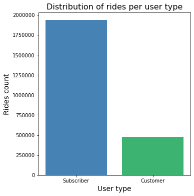

## Visualization 2: Number of rides per day of week

Next, we'll plot the distribution of rides in each day of the week, taking into account the information on the ride starting time.

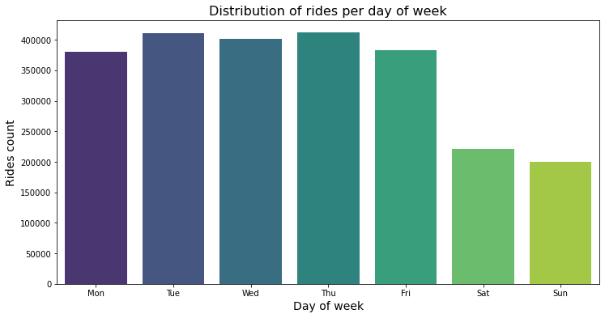

## Visualization 3: Mean trip duration per day of week and user type

Now we'll observe the relationship between bike ride duration, day of the week and user type.

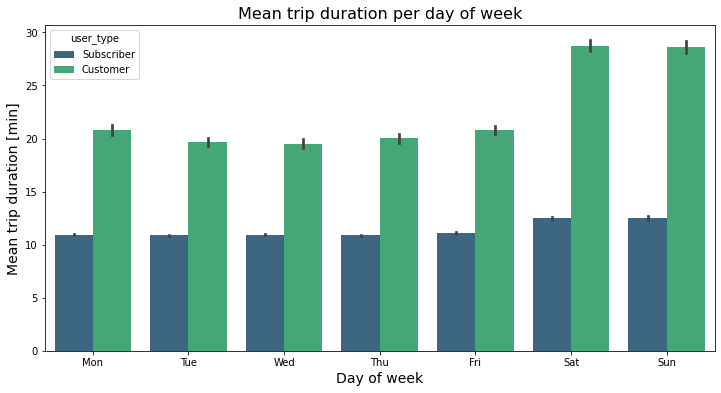

## Conclusions

- Approximately 80% of the people who use the bicycles are subscribers, while the remaining 20% are occasional users.
- The use of the bike sharing system remains almost constant during the week, but drops significantly on the weekends.
- On average, the duration of bike rides is longer for occasional customers than for subscribed users.
- Trip lengths are longer on the weekends, and this is mainly attributed to occasional users.